# Multiple Correspondence Analysis: Assignments

```r
summary(Finland2.mca2)
```

```
##
## Principal inertias (eigenvalues):
##
##  dim    value      %   cum%   scree plot
##  1      0.069858  40.4  40.4  **********
##  2      0.047719  27.6  68.0  *******
##  3      0.034199  19.8  87.8  *****
##  4      0.021173  12.2 100.0  ***
##         -------- -----
##  Total: 0.172949 100.0
##
##
## Rows:
##     name   mass  qlt  inr     k=1 cor ctr     k=2 cor ctr
## 1 |   A3 |   73  563  194 |  -418 384 184 |   286 179 126 |
## 2 |   B3 |   44  770  256 |  -623 389 246 |   616 381 353 |
## 3 |   C3 |   17  943  318 | -1267 491 387 | -1215 452 522 |
## 4 |   D3 |   52  317  232 |  -495 317 182 |     6   0   0 |
##
## Columns:
##     name   mass  qlt  inr     k=1 cor ctr     k=2 cor ctr
## 1 |   A3 |   73  563  194 |  -418 384 184 |   286 179 126 |
## 2 |   B3 |   44  770  256 |  -623 389 246 |   616 381 353 |
## 3 |   C3 |   17  943  318 | -1267 491 387 | -1215 452 522 |
## 4 |   D3 |   52  317  232 |  -495 317 182 |     6   0   0 |
```

Adding respondent points only for **middle** categories:

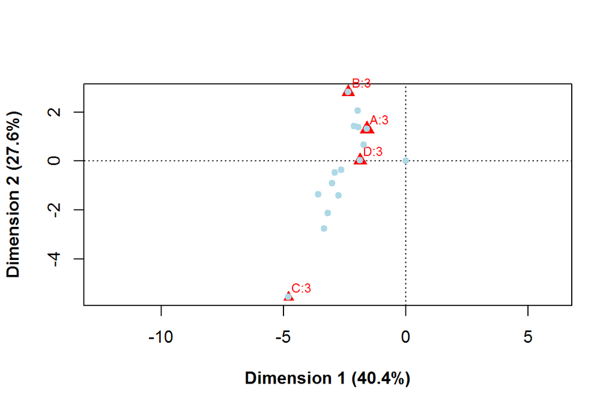

```r
#Finland2.Z - indicator matrix
# apply(variable, margin, function). - Returns a vector or array or list of values obtained by applying
#a function to margins of an array or matrix
#margin specifies if you want to apply by row (margin = 1),
#by column (margin = 2), or for each element (margin = 1:2).
Finland2.sum4 <- apply(Finland2.Z[,c(Finland2.middle)], 1, sum)
Finland2.sum4[Finland2.sum4==0] <- 1
Finland2.rpc5 <- Finland2.Z[,c(Finland2.middle)] %*% Finland2.mca2$colcoord / Finland2.sum4
plot(Finland2.mca2, what=c("none", "all"), mass=c(F,T), font.lab=2, map="rowprincipal")
points(Finland2.rpc5, pch=19, col="lightblue", cex=0.8)
```

Only **missing** categories are obtained as:

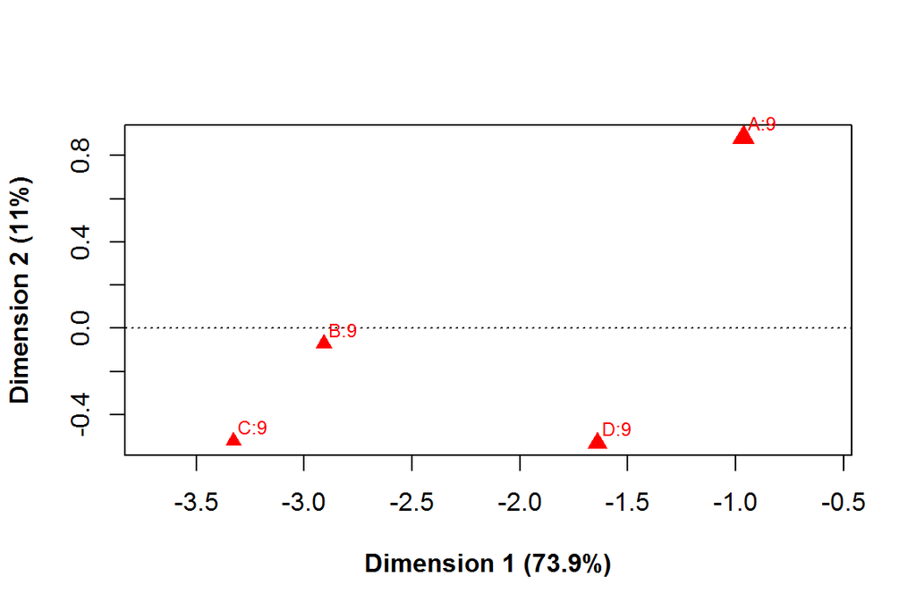

```r
Finland2.missing <- c(6,12,18,24)
Finland2.mca4 <- ca(Finland2.B, subsetrow=c(Finland2.missing), subsetcol=c(Finland2.missing))
plot(Finland2.mca4, what=c("none", "all"), mass=c(F,T), font.lab=2)
```

Adding respondent points only for **missing** categories:

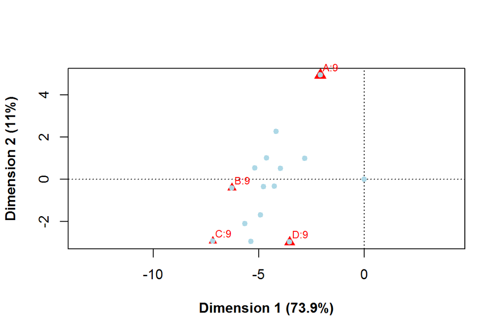

```r
Finland2.sum2 <- apply(Finland2.Z[,c(Finland2.missing)], 1, sum)
Finland2.sum2[Finland2.sum2==0] <- 1
Finland2.rpc3 <- Finland2.Z[,c(Finland2.missing)] %*% Finland2.mca4$colcoord / Finland2.sum2
plot(Finland2.mca4, what=c("none", "all"), mass=c(F,T), font.lab=2, map="rowprincipal")
points(Finland2.rpc3 , pch=19, col="lightblue", cex=0.8)
```

**Both “middle” and missing** categories are investigated again using CA of Burt matrix.

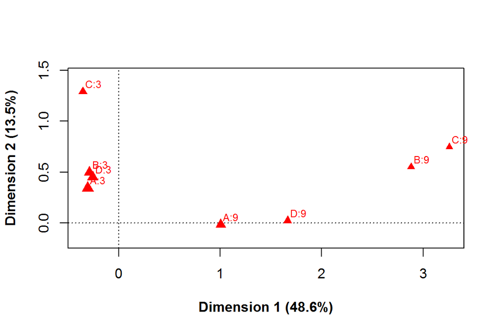

```r
Finland2.missing <- c(6,12,18,24)
Finland2.mca3 <- ca(Finland2.B, subsetrow=c(Finland2.middle,Finland2.missing), subsetcol=c(Finland2.middle,Finland2.missing))
plot(Finland2.mca3, what=c("none", "all"), mass=c(F,T), font.lab=2)
```

Adding respondent points only for **both “middle” and missing** categories:

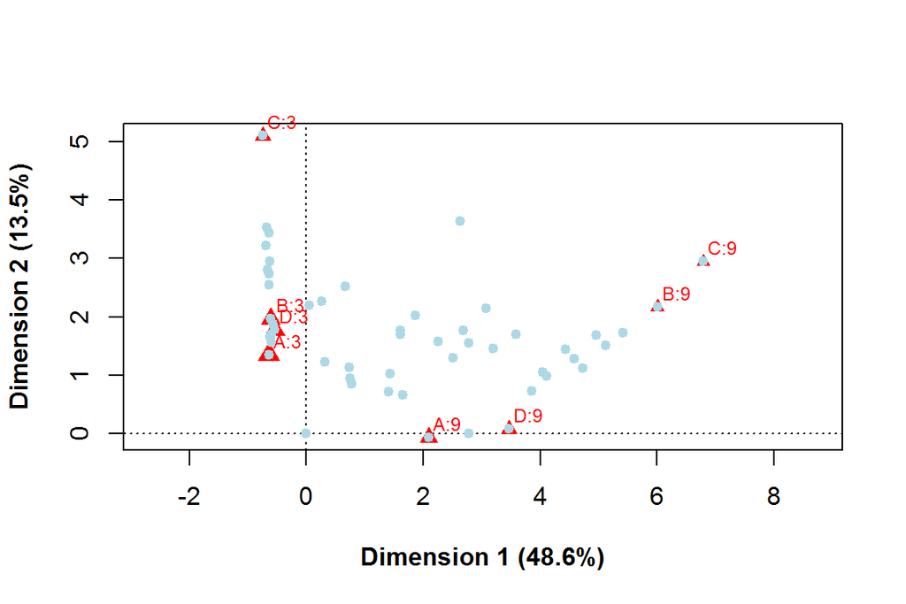

```r
Finland2.sum1 <- apply(Finland2.Z[,c(Finland2.middle,Finland2.missing)], 1, sum)
Finland2.sum1[Finland2.sum1==0] <- 1
Finland2.rpc2 <- Finland2.Z[,c(Finland2.middle,Finland2.missing)] %*% Finland2.mca3$colcoord / Finland2.sum1
plot(Finland2.mca3, what=c("none", "all"), mass=c(F,T), font.lab=2, map="rowprincipal")
points(Finland2.rpc2 , pch=19, col="lightblue", cex=0.8)
```

Next we compute confidence regions of demographic groups for **both missing and “middle”** groups.

- confidence plot for the demographic group **partnership**

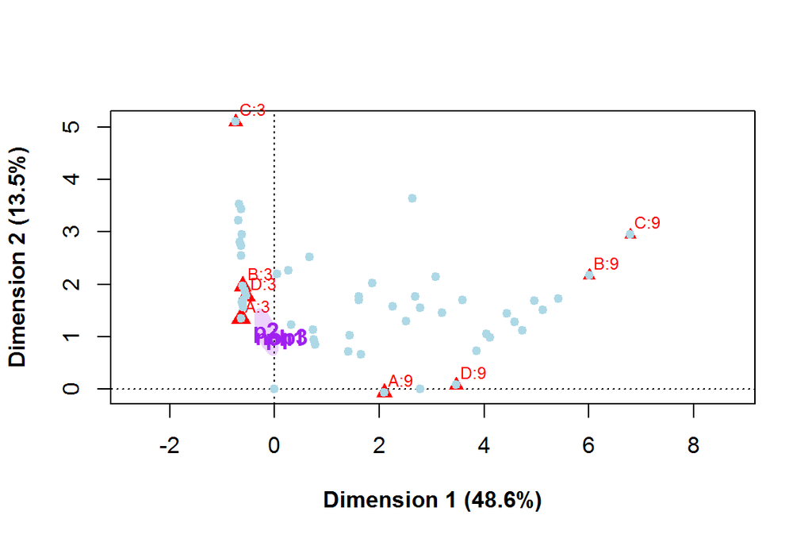

```r
#generated assymmetric plot
plot(Finland2.mca3, what=c("none", "all"), mass=c(F,T), font.lab=2, map="rowprincipal")
#add points
points(Finland2.rpc2, pch=19, col="lightblue", cex=0.8)
#draw confidence plots
confidenceplots(Finland2.rpc2[Finland2$p<4,1], Finland2.rpc2[Finland2$p<4,2], group=Finland2$p[Finland2$p<4], groupcols=rep("purple",5), shade=T,
                groupnames=c("ph1","p2","nop3"), shownames=T, add=T)
```

- confidence plot for the demographic group **education**

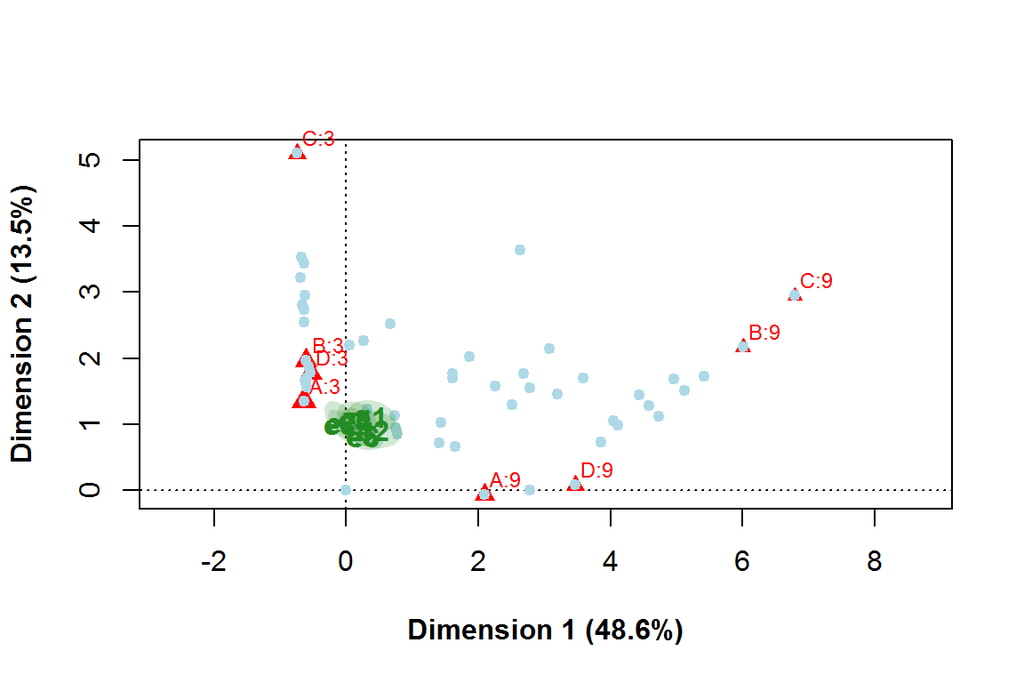

```r
plot(Finland2.mca3, what=c("none", "all"), mass=c(F,T), font.lab=2, map="rowprincipal")
points(Finland2.rpc2, pch=19, col="lightblue", cex=0.8)
confidenceplots(Finland2.rpc2[Finland2$e<9,1], Finland2.rpc2[Finland2$e<9,2], group=Finland2$e[Finland2$e<9], groupcols=rep("forestgreen",8), shade=T,
                groupnames=c("e1","e2","e3","e4","e5","e6","e7","e8"), shownames=T, add=T)
```

- confidence plot for the demographic group **gender**

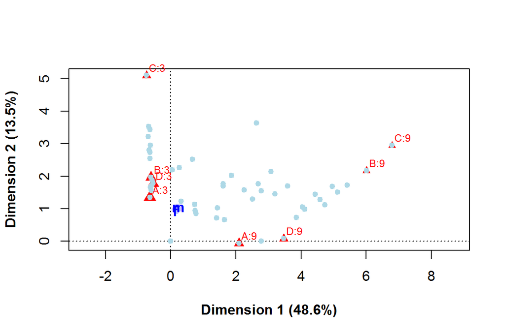

```r
plot(Finland2.mca3, what=c("none", "all"), mass=c(F,T), font.lab=2, map="rowprincipal")
points(Finland2.rpc2, pch=19, col="lightblue", cex=0.8)
confidenceplots(Finland2.rpc2[Finland2$g<3,1], Finland2.rpc2[Finland2$g<3,2], group=Finland2$g[Finland2$g<3], groupcols=rep("blue",6), shade=T,
                groupnames=c("m","f"), shownames=T, add=T)
```

- confidence plot for the demographic group **age**

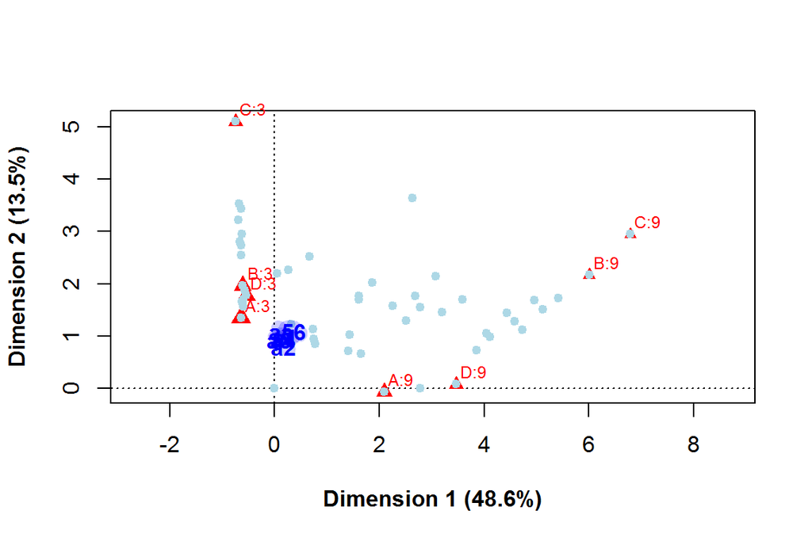

```r
plot(Finland2.mca3, what=c("none", "all"), mass=c(F,T), font.lab=2, map="rowprincipal")
points(Finland2.rpc2, pch=19, col="lightblue", cex=0.8)
confidenceplots(Finland2.rpc2[Finland2$a<7,1], Finland2.rpc2[Finland2$a<7,2], group=Finland2$a[Finland2$a<7], groupcols=rep("blue",6), shade=T,
                groupnames=c("a1","a2","a3","a4","a5","a6"), shownames=T, add=T)
```

Since from these plots the confidence regions are not so clear, similarly as in Task 2, we next plot **“just the ellipses”**.

- for the demographic group **partnership**:

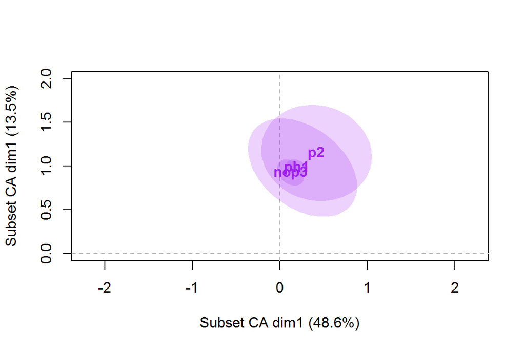

```r
plot(Finland2.rpc2, type="n", asp=1, xlab="Subset CA dim1 (48.6%)", ylab="Subset CA dim1 (13.5%)", xlim=c(-1,1), ylim=c(0,2))
abline(v=0, h=0, lty=2, col="grey")
#draw confidence plots
confidenceplots(Finland2.rpc2[Finland2$p<4,1], Finland2.rpc2[Finland2$p<4,2], group=Finland2$p[Finland2$e<4], groupcols=rep("purple",5), shade=T,
                groupnames=c("ph1","p2","nop3"), shownames=T, add=T)
```

- for the demographic group **education**:

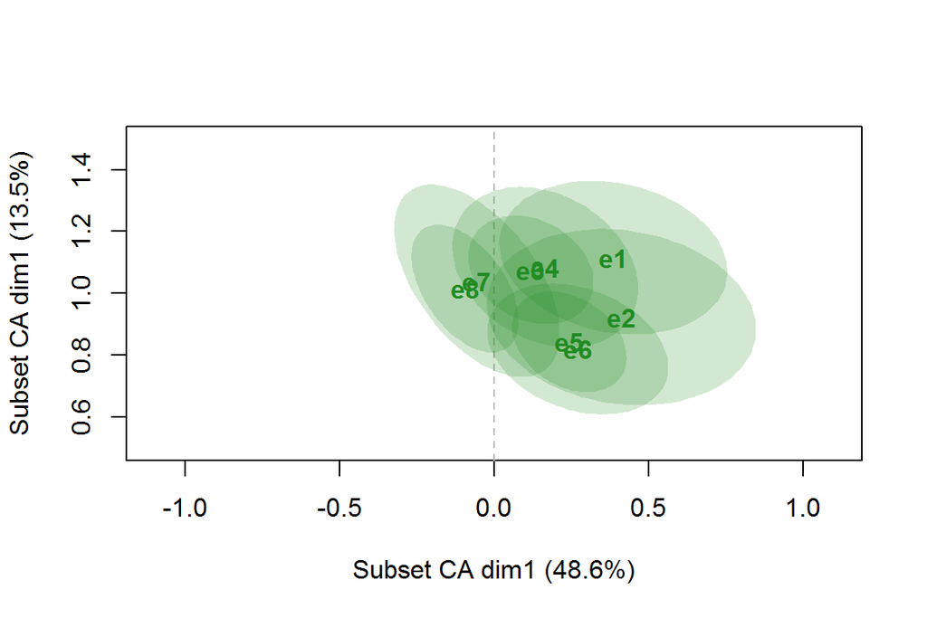

```r
plot(Finland2.rpc2, type="n", asp=1, xlab="Subset CA dim1 (48.6%)", ylab="Subset CA dim1 (13.5%)", xlim=c(-1,1), ylim=c(0.5,1.5))
abline(v=0, h=0, lty=2, col="grey")
confidenceplots(Finland2.rpc2[Finland2$e<9,1], Finland2.rpc2[Finland2$e<9,2], group=Finland2$e[Finland2$e<9], groupcols=rep("forestgreen",8), shade=T,
                groupnames=c("e1","e2","e3","e4","e5","e6","e7","e8"), shownames=T, add=T)
```

- for the demographic group **gender**:

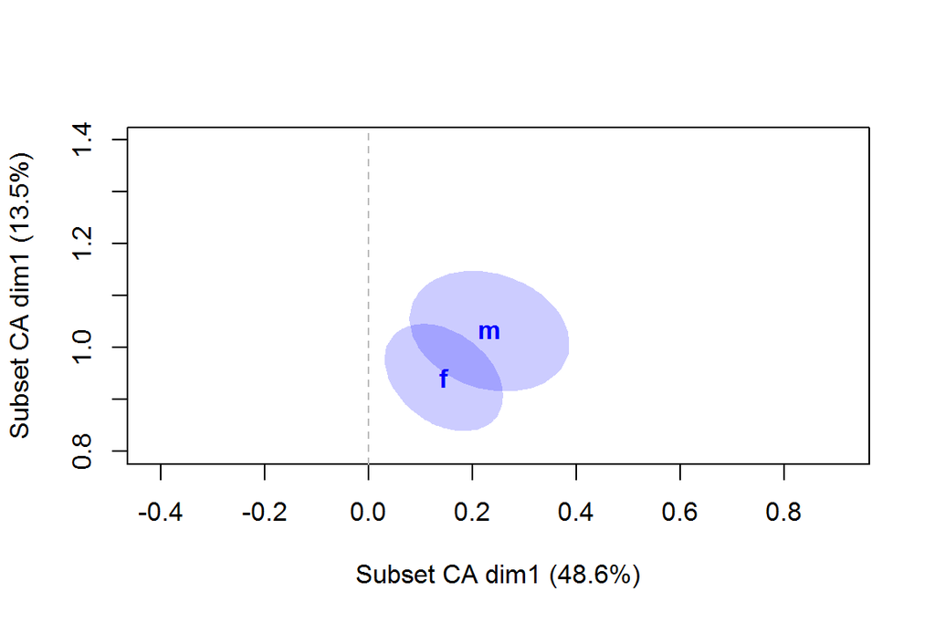

```r
plot(Finland2.rpc2, type="n", asp=1, xlab="Subset CA dim1 (48.6%)", ylab="Subset CA dim1 (13.5%)", xlim=c(0,0.5), ylim=c(0.8,1.4))
abline(v=0, h=0, lty=2, col="grey")
confidenceplots(Finland2.rpc2[Finland2$g<3,1], Finland2.rpc2[Finland2$g<3,2], group=Finland2$g[Finland2$g<3], groupcols=rep("blue",6), shade=T,
                groupnames=c("m","f"), shownames=T, add=T)
```

- for the demographic group **age**:

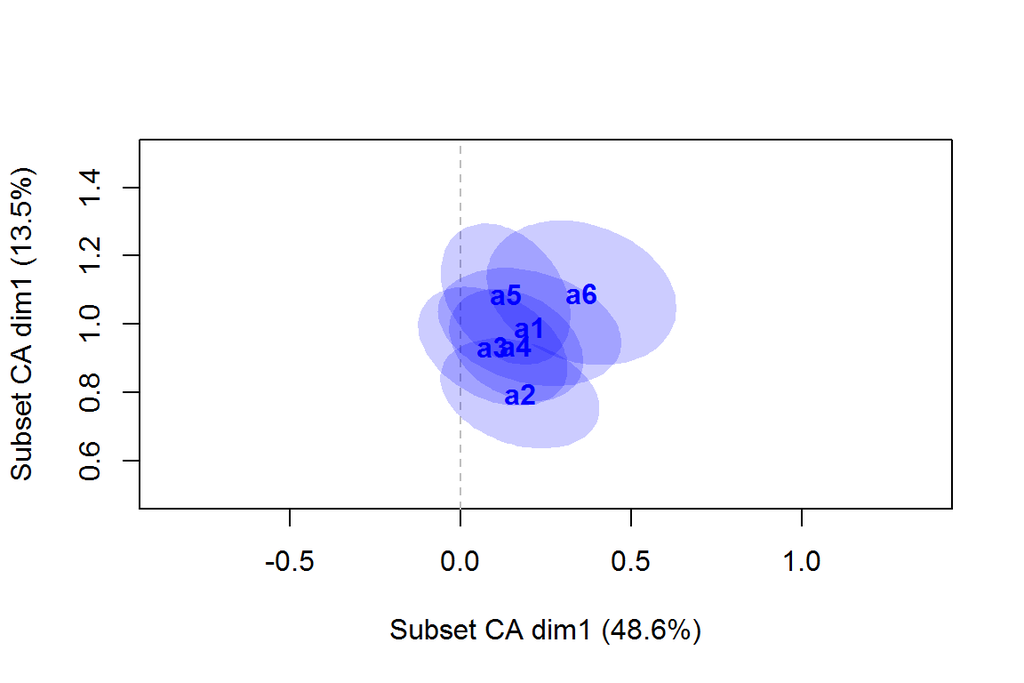

```r
plot(Finland2.rpc2, type="n", asp=1, xlab="Subset CA dim1 (48.6%)", ylab="Subset CA dim1 (13.5%)", xlim=c(-0.5,1), ylim=c(0.5,1.5))
abline(v=0, h=0, lty=2, col="grey")
confidenceplots(Finland2.rpc2[Finland2$a<7,1], Finland2.rpc2[Finland2$a<7,2], group=Finland2$a[Finland2$a<7], groupcols=rep("blue",6), shade=T,
                groupnames=c("a1","a2","a3","a4","a5","a6"), shownames=T, add=T)
```

From all analyses, provided in Task 3, we can conclude that MCA is a powerful tool for investigating missing and “middle” categories. Both categories involve quite big amount of uncertainty, because of which most of the other methods just ignore these cases. Here we have seen how the information from both categories could be utilized applying MCA approach.

## Used and useful links

[Package ca](https://cran.r-project.org/web/packages/ca/ca.pdf)

[Oleg Nenadic and Michael Greenacre, Computation of Multiple Correspondence Analysis, with code in R](https://core.ac.uk/download/pdf/6591520.pdf)

[Michael Greenacre, Biplots in practise](http://www.multivariatestatistics.org/biplots.html)

Multiple Correspondence Analysis Essentials: Interpretation and application to investigate the associations between categories of multiple qualitative variables - R software and data mining

Mike Bendixen, A Practical Guide to the Use of Correspondence Analysis in Marketing Research, Marketing Bulletin, 2003, 14, Technical Note 2.

[An Example R Markdown] (http://www.statpower.net/Content/310/R%20Stuff/SampleMarkdown.html)

[Writing Mathematic Fomulars in Markdown](http://csrgxtu.github.io/2015/03/20/Writing-Mathematic-Fomulars-in-Markdown/)

# MULTIPLE CORRESPONDANCE ANALYSIS - Assignment 3

# The data

As during the Assignment set 1. here we again use **Finnish** sample from [ISSP 2012 survey “Family and Changing Gender Roles IV”](http://www.gesis.org/issp/modules/issp-modules-by-topic/family-and-changing-gender-roles/2012/). Original data involve 1171 observations of 8 variables (4 substantive and 4 demographic). All variables are categorical.

The 4 **substantive** variables, which values are measured in 1-5 scale, are:

**A**: Married people are generally happier than unmarried people.  
**B**: People who want children ought to get married.  
**C**: It is all right for a couple to live together without intending to get married.  
**D**: Divorce is usually the best solution when a couple can’t seem to work out their marriage problems.

The **demographic** variables are:  
**g**: gender (1=male, 2=female)  
**a**: age group (1=16-25, 2=26-35, 3=36-45, 4=46-55, 5=56-65, 6= 66+)  
**e**: education (1=Primary, 2=Comprehensive, primary and lower secondary, 3= Post-comprehensive, vocational school or course, 4=General upper secondary education or certificate, 5= Vocational post-secondary non-tertiary education, 6=Polytechnics, 7= University, lower academic degree, BA, 8=University, higher academic degree, MA  
**p**: Living in steady partnership (1=Yes, have partner; live in same household, 2=Yes, have partner; don’t live in same household, 3=No partner)

The data wrangling includes the following changes:

1. The missing data ae removed (this has already been provided). The number of observations without missing data is N=924.
2. We again use a combined variable **ga = 6*(g-1) + a**. The combined variable** ga** describes the interaction of gender and age categories.

## Graphical overview of the data and summaries of the variables

The preliminary treated data look as:

```r
Finland <- read.table("Finland.txt")
Finland$ga <- 6*(Finland$g-1) + Finland$a
head(Finland)
```

```
##   A B C D g a e p ga
## 1 3 3 1 2 1 2 4 3  2
## 2 3 2 3 2 1 4 2 3  4
## 3 3 3 1 3 1 3 8 1  3
## 4 3 2 2 3 2 2 6 1  8
## 5 2 2 2 3 2 4 5 1 10
## 6 3 3 1 3 1 3 7 3  3
```

```r
dim(Finland)
```

```
## [1] 924   9
```

```r
str(Finland)
```

```
## 'data.frame':    924 obs. of  9 variables:
##  $ A : int  3 3 3 3 2 3 3 2 2 3 ...
##  $ B : int  3 2 3 2 2 3 3 3 3 3 ...
##  $ C : int  1 3 1 2 2 1 1 1 2 3 ...
##  $ D : int  2 2 3 3 3 3 2 2 3 3 ...
##  $ g : int  1 1 1 2 2 1 2 2 2 2 ...
##  $ a : int  2 4 3 2 4 3 1 2 5 4 ...
##  $ e : int  4 2 8 6 5 7 4 8 7 5 ...
##  $ p : int  3 3 1 1 1 3 3 3 1 3 ...
##  $ ga: num  2 4 3 8 10 3 7 8 11 10 ...
```

```r
library(FactoMineR)
library(tidyr)
library(ggplot2)
library(dplyr)
keep_columns <- c("A", "B", "C", "D", "g", "a", "e", "p", "ga")
Finland <- dplyr::select(Finland, one_of(keep_columns))
summary(Finland)
```

```
##        A               B               C               D
##  Min.   :1.000   Min.   :1.000   Min.   :1.000   Min.   :1.000
##  1st Qu.:2.000   1st Qu.:2.000   1st Qu.:1.000   1st Qu.:2.000
##  Median :3.000   Median :3.000   Median :2.000   Median :2.000
##  Mean   :3.193   Mean   :3.025   Mean   :1.835   Mean   :2.503
##  3rd Qu.:4.000   3rd Qu.:4.000   3rd Qu.:2.000   3rd Qu.:3.000
##  Max.   :5.000   Max.   :5.000   Max.   :5.000   Max.   :5.000
##        g               a               e               p
##  Min.   :1.000   Min.   :1.000   Min.   :1.000   Min.   :1.000
##  1st Qu.:1.000   1st Qu.:2.000   1st Qu.:3.000   1st Qu.:1.000
##  Median :2.000   Median :4.000   Median :5.000   Median :1.000
##  Mean   :1.563   Mean   :3.644   Mean   :4.527   Mean   :1.563
##  3rd Qu.:2.000   3rd Qu.:5.000   3rd Qu.:6.000   3rd Qu.:3.000
##  Max.   :2.000   Max.   :6.000   Max.   :8.000   Max.   :3.000
##        ga
##  Min.   : 1.000
##  1st Qu.: 4.000
##  Median : 7.000
##  Mean   : 7.021
##  3rd Qu.:10.000
##  Max.   :12.000
```

We present data graphically as barplots using ggplot() function.

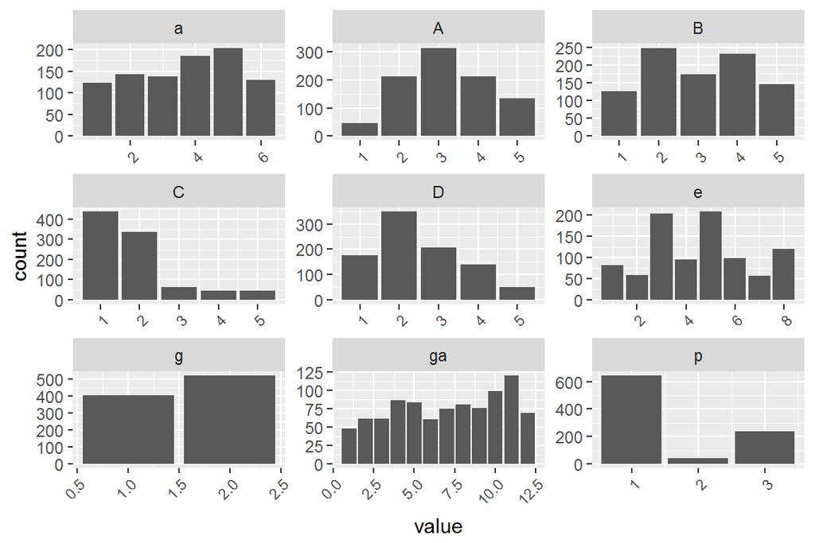

```r
gather(Finland) %>% ggplot(aes(value)) + facet_wrap("key", scales = "free") + geom_bar()+theme(axis.text.x = element_text(angle = 45, hjust = 1, size = 8))
```

# Nonlinear MCA: The package homals in R

There are two main constrained forms of MCA: canonical MCA and nonlinear MCA. Canonical MCA use explanatory variables to explain set of response variables, while in classical MCA there is no restriction imposed by explanatory variables since all variables are assumed to be response variables.

Nonlinear MCA is also assumed to be a constrained form of MCA because it is obtained from common MCA (known also as homogeneity analysis) by imposing restrictions on the variable ranks and levels as well as defined set of variables.

The most important advantages of nonlinear over linear MCA are that except truly numeric nonlinear MCA incorporates nominal and ordinal variables, and additionally can discover nonlinear relationships between variables.

In nonlinear MCA the variables could be nominal, ordinal or true numeric. Nominal variables consist of unordered categories. Since principal components are weighted sums of the original variables, nominal variables could not be analyzed using standard linear PCA. Ordinal variables consist of ordered categories, for example as we have also used, a Likert-type scale. Such scale values are not truly numeric because intervals between consecutive categories are not equal. Although ordinal variables display more structure than nominal ones, these variables still do not possess traditional numeric properties. The true numeric variables can be viewed as categorical with *c* categories, where *c* indicates the number of different observed values. Both ratio and interval variables are considered numeric in nonlinear PCA.

Linear MCA is suitable for variables, all measured as numeric. It is possible to exist nonlinear relationships between some of these variables. Then nonlinear MCA will be more appropriate approach.

Nonlinear PCA converts categories into numeric values because the variance could be established only for numeric values. This process is called quantification. Thus correlations are not computed between observed variables, but between quantified variables. Therefore the correlation matrix in nonlinear PCA is not fixed and depends on the type of quantification chosen for every variable.

The type of quantification is called analysis level. Different analysis levels imply different requirements.

Nonlinear MCA in R could be provided by using the **homals** package. This package performs simple homogeneity analysis, which corresponds to MCA. The package **homals** also provide some extensions to MCA, including nonlinear MCA. Nonlinear PCA could be provided using the function **homals** and setting appropriate options.

In the example below we use “ordinal” analysis level because the substantive variables are ordinal and the categories are given in Likert-type scale.

```r
require(homals)
#algebraically, the geometric concept of dimensionality is related to
#the rank of the matrix, which has to be reduced.
#rank - Which quantification ranks. Default is number of dimensions ndim
#level - Which quantification levels. Possible values are "nominal", "ordinal",
#"numerical", and "polynomial" which can be defined as
#single character (if all variable are of the same level) or
#as vector which length corresponds to the number of variables

Finland.nlpca <- homals(Finland[,1:4], rank=1, level="ordinal")
```

## 1. Transformation plots

Next the transformation plot is drawn. The horizontal axis (x) of the plot displays the categories (1 to 5) of the ordinal substantive variables. On the vertical axis (y) the category quantification for every substantive variable (A-D) are shown.

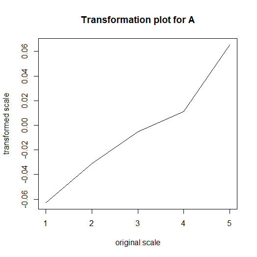

Figure 1A

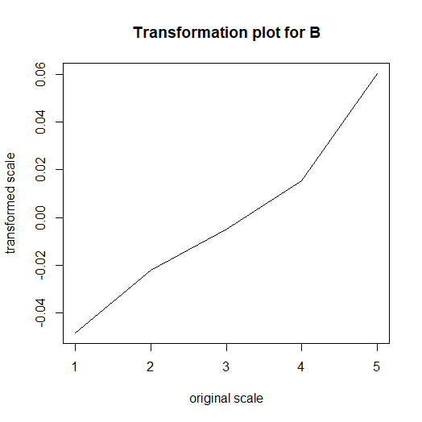

Figure 1B

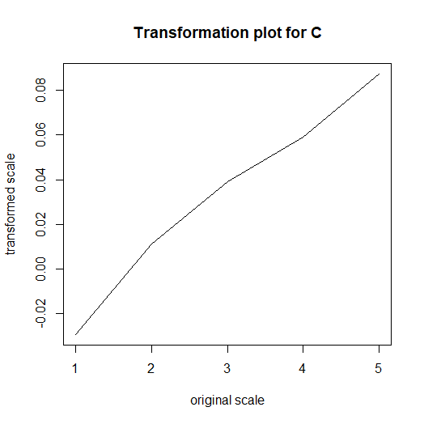

Figure 1C

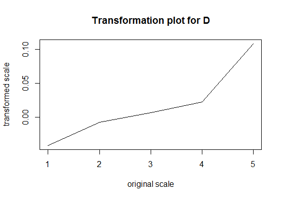

Figure 1D

```r
#Transformation plot: Plots the original (categorical) scale against
#the transformed (metric) scale on each dimension over the categories
#of each variable separately.
plot(Finland.nlpca, plot.type="trfplot")    # relationship of transformed scale with 1-to-5 scale
```

From the transformation plot for the variable D we see that the ordinal category quantification are non-strictly increasing with the original category labels. The original spacing between categories is not maintained in the quantifications. Between categories 2 and 4 we see something similar to plateau, which means that some consecutive categories obtain almost the same quantification, called ties. There are two possible reasons for such ties: 1. The persons scoring in the tied categories do not structurally differ from each other considering their scores on the other variables, and therefore categories cannot be distinguished from each other. 2. The ordinal quantifications are obtained by placing an order restriction on nominal quantifications.

## 2.Category plots

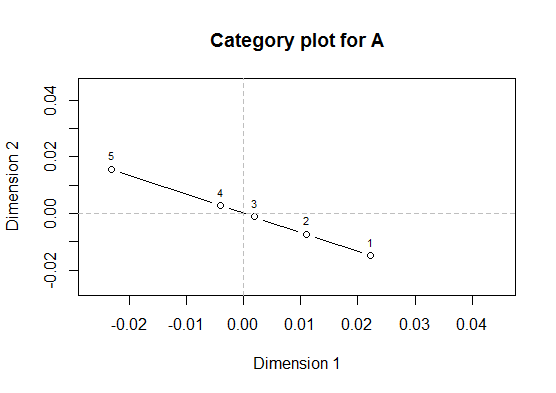

Figure 2A

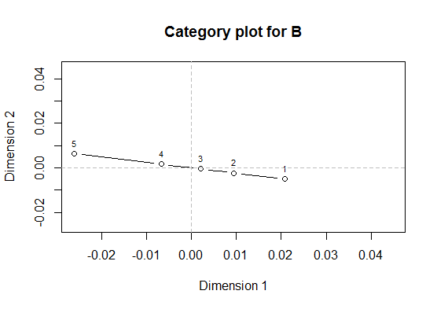

Figure 2B

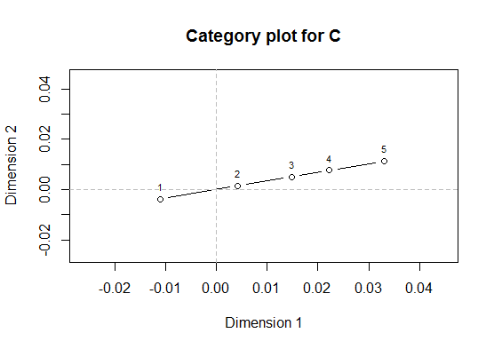

Figure 2C

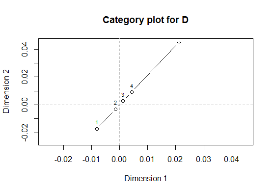

Figure 2D

```r
#2. Category plot: Plots the rank-restricted category quantifications for
#each variable separately.
plot(Finland.nlpca, plot.type="catplot")
```

In these plots the loading point is not shown. I do not know how to interpret the nonlinear transformations, which lead to these 4 category plots.

## 3.Component loadings plot

In these plots only the loading vectors (origin and loading point) are displayed. Here the variables with relatively long vectors fit well into the solution and variables with relatively short vectors fit badly. When vectors are long, the cosines of the angles between the vectors indicate the correlation between the quantified variables. The length of the variable vector from the origin up to the component loading point is an indication of the variable’s total variance accounted for (VAF). Thus VAF can be interpreted as the amount of information retained when variables are represented in a lower dimensional space. Nonlinear transformations reduce the dimensionality necessary to represent the variables satisfactory.

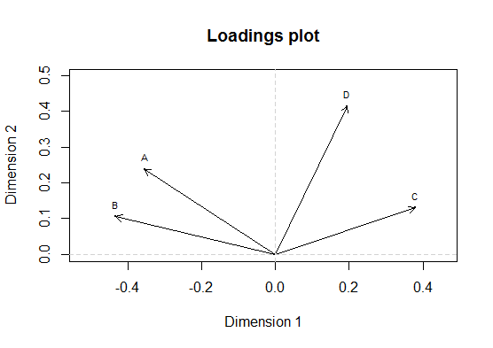

Figure 3

```r
#3. Loadings plot: Plots the loadings of the variables and connects them with the origin.
plot(Finland.nlpca, plot.type="loadplot")
```

In this example the longest length has a variable vector for D. Other variable vector lengths are very similar and not much shorter than D loading vector.

## 4.Vector plot

In this plot all cases (object scores) are projected onto a straight line defined by each rank restricted category quantified variable. Here except the straight line, plotted in the category plots, also all object scores are shown.

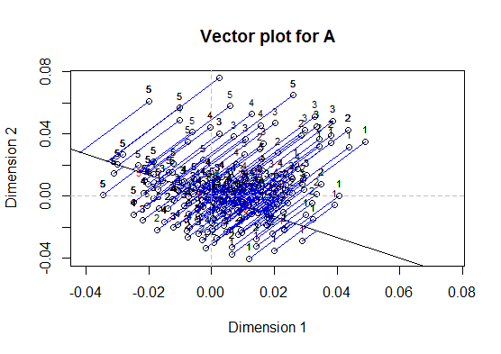

Figure 4A

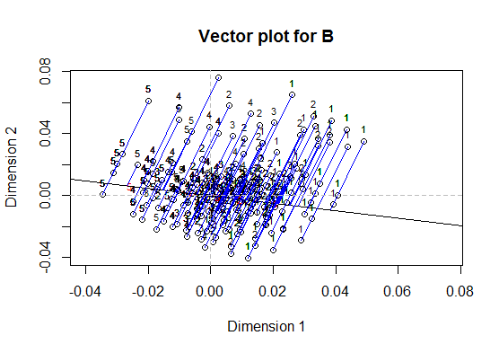

Figure 4B

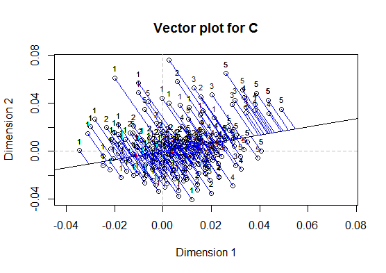

Figure 4C

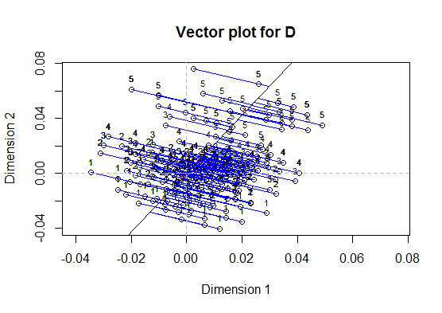

```r
#4. Vector plot: cases projected onto straight line defined by each variable
plot(Finland.nlpca, plot.type="vecplot")
```

##5.Loss plot

The loss plot shows the rank-restricted category quantifications against the unrestricted for each variable separately. It actually compares MCA and NLPCA.

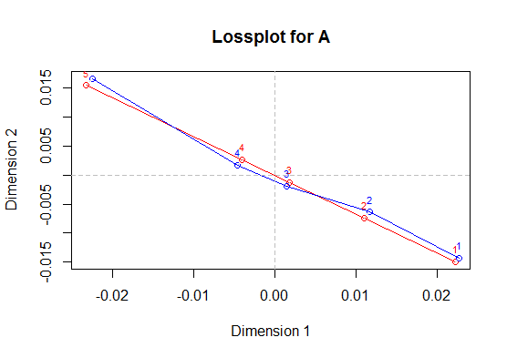

Figure 5A

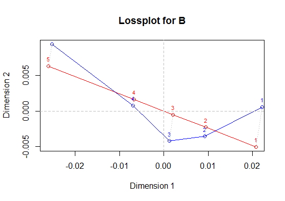

Figure 5B

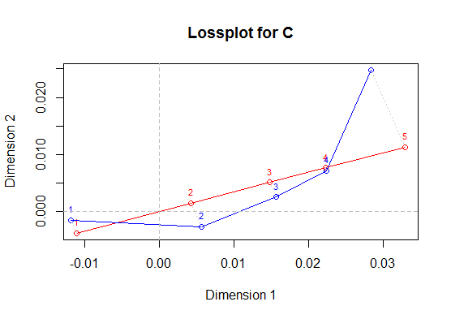

Figure 5C

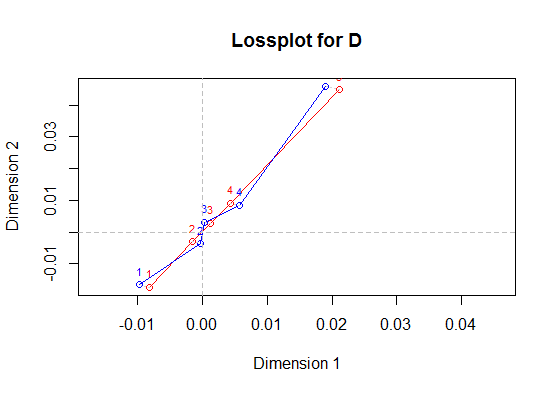

```r
plot(Finland.nlpca, plot.type="lossplot")
```

From these plots we see that the linear and nonlinear MCA results are very near for variables A and D, while both model outputs differ quite a lot for the variables B and C. This could mean that linear model assumption for variables A and D is appropriate.

## 6. Object plot

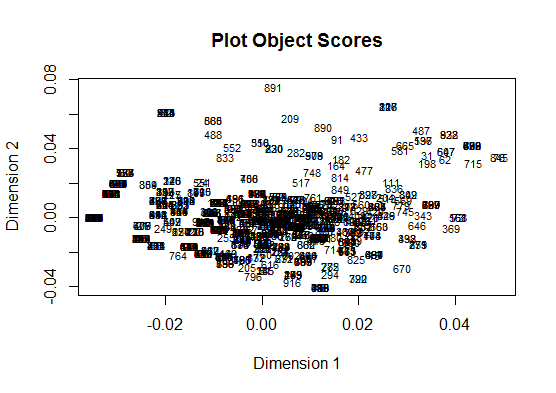

Figure 6

```r
plot(Finland.nlpca, plot.type="objplot")
```

## 7. Label plot

It is similar to the previous object plot. In the label plot the object scores are also plotted, but now for each variable separately with the corresponding category labels. It looks like contour lines forced to be straight & parallel

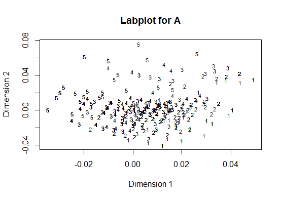

Figure 7A

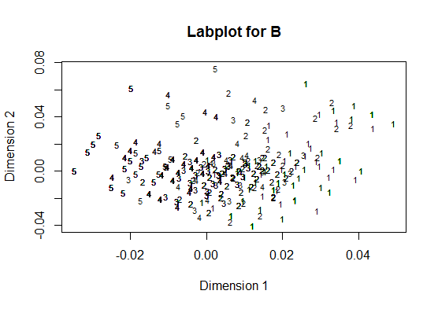

Figure 7B

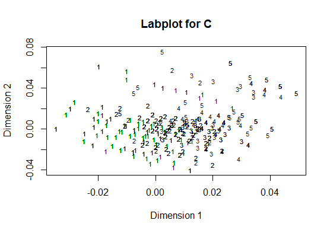

Figure 7C

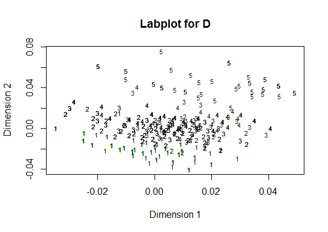

```r
plot(Finland.nlpca, plot.type="labplot")
```

#8. Graph plot.

It is a joint plot with connections between scores/quantifications. So, except the object scores, plotted on object plot, the variable quantifications are also shown. It should be noted that this plot works only for small data sets. Even in the provided example ot is already quite difficult to observe the plotted relationships.

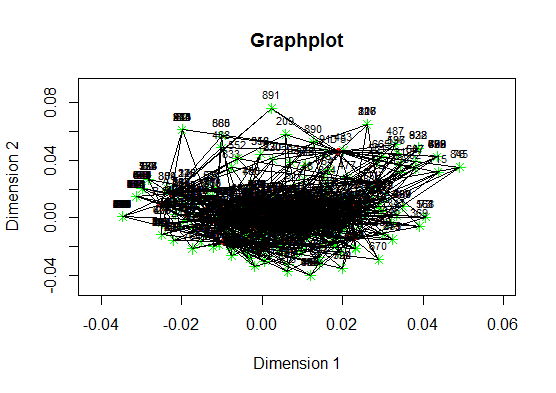

Figure 8

```r
plot(Finland.nlpca, plot.type="graphplot")
```

## 9. Voronoi plot.

It produces a category plot with Voronoi regions. Looks like contour lines forced to be straight and parallel.

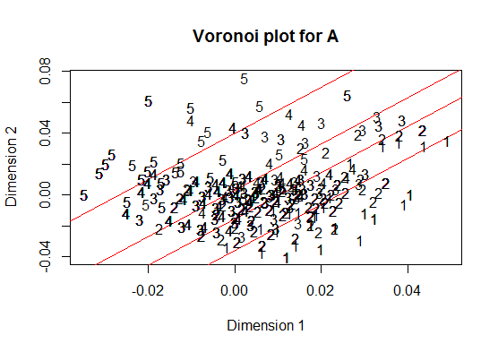

Figure 9A

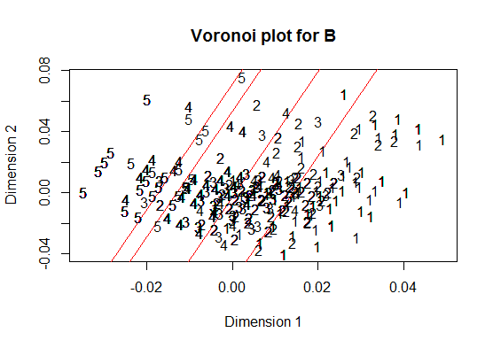

Figure 9B

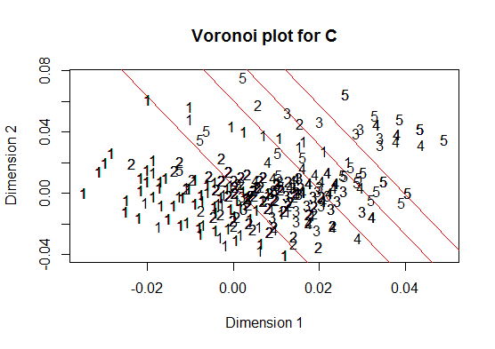

Figure 9C

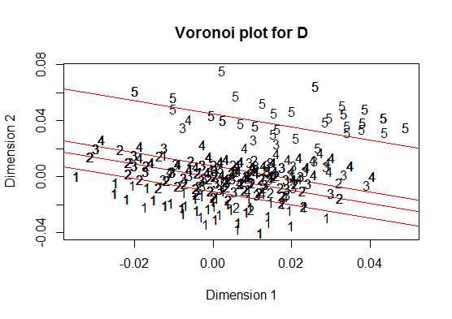

Figure 9D

```r
plot(Finland.nlpca, plot.type="vorplot")
```

## 10. Hull plot

For each single variable the object scores are mapped onto two dimensions and the convex hull for each response category is drawn.

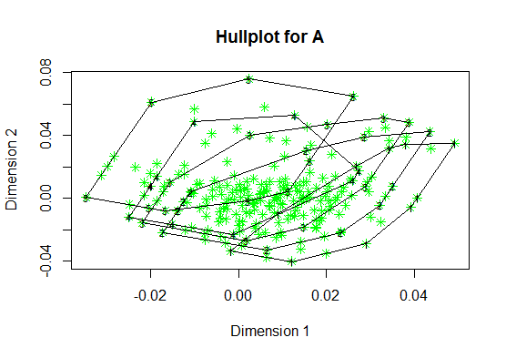

Figure 10A

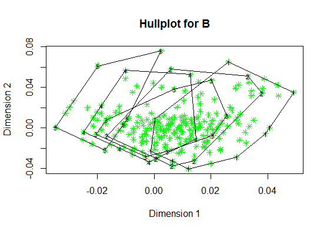

Figure 10B

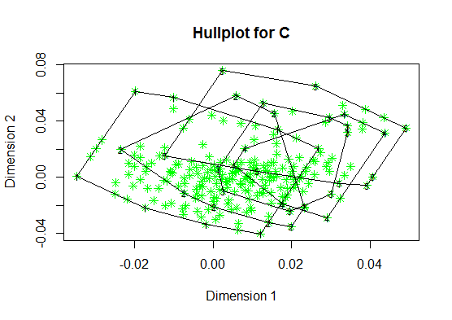

Figure 10C

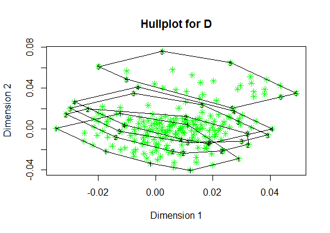

Figure 10D

```r
# would be better to show confidence ellipses
plot(Finland.nlpca, plot.type="hullplot")
```

# CA of doubled data

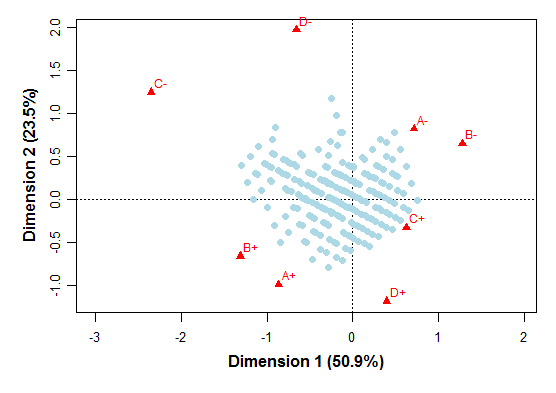

Figure 11

```r
require(ca)
Finland.doubled <- cbind( (Finland[,1:4]-1), (5-Finland[,1:4]) )
colnames(Finland.doubled) <- paste( rep(LETTERS[1:4],2), rep(c("-","+"), each=4), sep="" )
head(Finland.doubled)
Finland.doubled.ca <- ca(Finland.doubled)
par(mar=c(4.2,4,1,1), mgp=c(2,0.7,0), font.lab=2, cex.axis=0.8)
plot(Finland.doubled.ca, col=c("lightblue","red"), labels=c(0,2), font=2, map="rowprincipal")
```

Next we connect opposite categories in column standard coordinates and draw the contribution biplot.

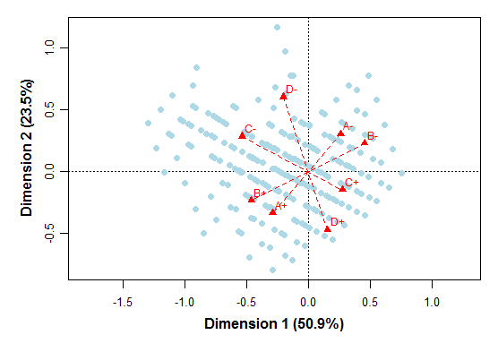

Figure 12

```r
# connect opposite categories in column standard coordinates
Finland.doubled.csc <- Finland.doubled.ca$colcoord
for(j in 1:4) segments(Finland.doubled.csc[j,1],Finland.doubled.csc[j,2],
                       Finland.doubled.csc[4+j,1],Finland.doubled.csc[4+j,2], col="red", lty=2)
par(mar=c(4.2,4,1,1), mgp=c(2,0.7,0), font.lab=2, cex.axis=0.8)
plot(Finland.doubled.ca, col=c("lightblue","red"), labels=c(0,2), font=2, map="rowgreen")
Finland.doubled.ccc <- Finland.doubled.ca$colcoord * sqrt(Finland.doubled.ca$colmass)
for(j in 1:4) segments(Finland.doubled.ccc[j,1],Finland.doubled.ccc[j,2],
                       Finland.doubled.ccc[4+j,1],Finland.doubled.ccc[4+j,2], col="red", lty=2)
```

The polar positions in contribution coordinates are shown on Figure 13.

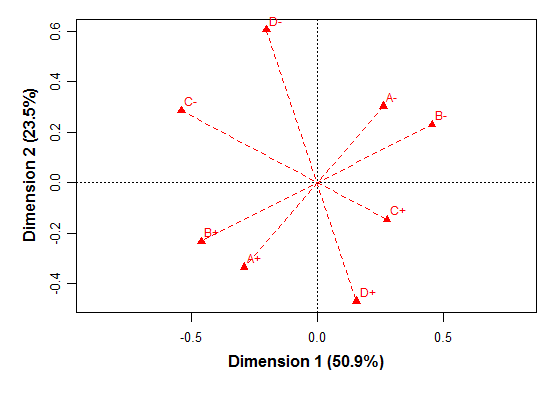

Figure 13

```r
# just the polar positions in contribution coordinates
par(mar=c(4.2,4,1,1), mgp=c(2,0.7,0), font.lab=2, cex.axis=0.8)
plot(Finland.doubled.ca, what=c("none","all"), labels=c(0,2), font=2, map="rowgreen")
for(j in 1:4) segments(Finland.doubled.ccc[j,1],Finland.doubled.ccc[j,2],
                       Finland.doubled.ccc[4+j,1],Finland.doubled.ccc[4+j,2], col="red", lty=2)
```

The demographic group averages are shown on Figure 14

```r
Finland.doubled.rpc <- Finland.doubled.ca$rowcoord %*% diag(Finland.doubled.ca$sv)
```

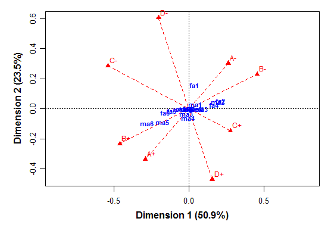

Figure 14

The demographic group averages and confidence regions are shown on Figure 15

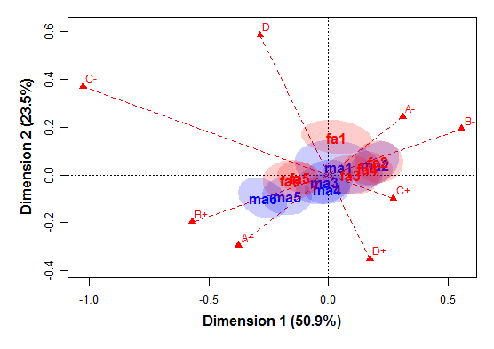

Figure 15

```r
# add centroids of demographic categories
Finland.doubled.rpc <- Finland.doubled.ca$rowcoord %*% diag(Finland.doubled.ca$sv)
# with confidence ellipses
source("confidenceplots.R")
require(ellipse)
par(mar=c(4.2,4,1,1), mgp=c(2,0.7,0), font.lab=2, cex.axis=0.8)
plot(Finland.doubled.ca, labels=c(0,2), what=c("none","all"))
Finland.doubled.cpc <- Finland.doubled.ca$colcoord %*% diag(Finland.doubled.ca$sv)
for(j in 1:4) segments(Finland.doubled.cpc[j,1],Finland.doubled.cpc[j,2],
                       Finland.doubled.cpc[4+j,1],Finland.doubled.cpc[4+j,2], col="red", lty=2)
confidenceplots(Finland.doubled.rpc[,1], Finland.doubled.rpc[,2], group=Finland$ga, groupcols=c(rep("blue",6),rep("red",6)), shade=T,
                groupnames=c("ma1","ma2","ma3","ma4","ma5","ma6","fa1","fa2","fa3","fa4","fa5","fa6"),shownames=T, add=T)
```

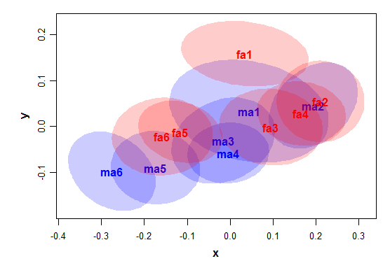

Figure 16

```r
#ellipses just by themselves (watch out for aspect ratio distortion! I have to correct this in next version of my function)
confidenceplots(Finland.doubled.rpc[,1], Finland.doubled.rpc[,2], group=Finland$ga, groupcols=c(rep("blue",6),rep("red",6)), shade=T,
                groupnames=c("ma1","ma2","ma3","ma4","ma5","ma6","fa1","fa2","fa3","fa4","fa5","fa6"),shownames=T, add=F)
```

# Regular PCA on non-missing data

The regular PCA plot is shown on the next Figure 17:

```r
Finland.pca <- prcomp(Finland[,1:4])
names(Finland.pca)
```

```
## [1] "sdev"     "rotation" "center"   "scale"    "x"
```

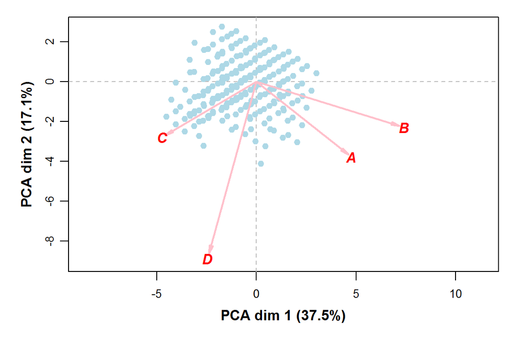

```r
# [1] "sdev"     "rotation" "center"   "scale"    "x"

par(mar=c(4.2,4,1,1), mgp=c(2,0.7,0), font.lab=2, cex.axis=0.8)
plot(rbind(Finland.pca$x, 10.5*Finland.pca$rotation), type="n", asp=1, xlab="PCA dim 1 (37.5%)", ylab="PCA dim 2 (17.1%)")
abline(h=0, col="gray", lty=2)
abline(v=0, col="gray", lty=2)
points(Finland.pca$x, pch=19, col="lightblue", cex=0.9)
arrows(0, 0, 10*Finland.pca$rotation[,1], 10*Finland.pca$rotation[,2], length=0.1, angle=10, col="pink", lwd=2)
text(10.3*Finland.pca$rotation, labels=colnames(Finland[,1:4]), col="red", font=4)
```

# Factor analysis

The R function factanal() performs the analysis on standardized variables

The correlation matrix is:

```r
round(cor(Finland[,1:4]),3)
```

```
##        A      B      C      D
## A  1.000  0.527 -0.236 -0.057
## B  0.527  1.000 -0.508 -0.138
## C -0.236 -0.508  1.000  0.291
## D -0.057 -0.138  0.291  1.000
```

Since 2 factors are too many for 4 variables, we have to set factors = 1.

```r
Finland.fa <- factanal(Finland[,1:4], factors=1, rotation="none", scores="regression")
names(Finland.fa)
```

```
##  [1] "converged"    "loadings"     "uniquenesses" "correlation"
##  [5] "criteria"     "factors"      "dof"          "method"
##  [9] "scores"       "STATISTIC"    "PVAL"         "n.obs"
## [13] "call"
```

```r
print(Finland.fa)
```

```
##
## Call:
## factanal(x = Finland[, 1:4], factors = 1, scores = "regression",     rotation = "none")
##
## Uniquenesses:
##     A     B     C     D
## 0.715 0.028 0.735 0.979
##
## Loadings:
##   Factor1
## A  0.534
## B  0.986
## C -0.515
## D -0.144
##
##                Factor1
## SS loadings      1.543
## Proportion Var   0.386
##
## Test of the hypothesis that 1 factor is sufficient.
## The chi square statistic is 65.38 on 2 degrees of freedom.
## The p-value is 6.35e-15
```

Factor analysis results:

[figure not shown]

```r
par(mar=c(4.2,4,1,1), mgp=c(2,0.7,0), font.lab=2, cex.axis=0.8)
plot(rbind(-Finland.fa$loadings, -0.5*Finland.fa$scores), asp=1, type="n", xlab="FA factor 1 (26.6%)", ylab="FA factor 2 (7.3%")
abline(h=0, col="gray", lty=2)
abline(v=0, col="gray", lty=2)
points(-0.5*Finland.fa$scores, pch=19, col="lightblue", cex=0.9)
arrows(0, 0, -Finland.fa$loadings[,1], -Finland.fa$loadings[,1], length=0.1, angle=10, col="pink", lwd=2)
text(-1.05*Finland.fa$loadings, labels=colnames(Finland[,1:4]), col="red", font=4)
```

FA with rotation:

```r
Finland.fa <- factanal(Finland[,1:4], factors=1, rotation="varimax", scores="regression")

print(Finland.fa)
```

```
##
## Call:
## factanal(x = Finland[, 1:4], factors = 1, scores = "regression",     rotation = "varimax")
##
## Uniquenesses:
##     A     B     C     D
## 0.715 0.028 0.735 0.979
##
## Loadings:
##   Factor1
## A  0.534
## B  0.986
## C -0.515
## D -0.144
##
##                Factor1
## SS loadings      1.543
## Proportion Var   0.386
##
## Test of the hypothesis that 1 factor is sufficient.
## The chi square statistic is 65.38 on 2 degrees of freedom.
## The p-value is 6.35e-15
```

Plot FA results:

[figure not shown]

```r
par(mar=c(4.2,4,1,1), mgp=c(2,0.7,0), font.lab=2, cex.axis=0.8)
plot(rbind(-Finland.fa$loadings, -0.5*Finland.fa$scores), asp=1, type="n", xlab="FA factor 1 (18.6%)", ylab="FA factor 2 (15.3%")
abline(h=0, col="gray", lty=2)
abline(v=0, col="gray", lty=2)
points(-0.5*Finland.fa$scores, pch=19, col="lightblue", cex=0.9)
arrows(0, 0, -Finland.fa$loadings[,1], -Finland.fa$loadings[,1], length=0.1, angle=10, col="pink", lwd=2)
text(-1.05*Finland.fa$loadings, labels=colnames(Finland[,1:4]), col="red", font=4)
```

# K-means clustering of respondents using MCA coordinates

Finland is the set of complete cases

```r
require(ca)
Finland.B <- mjca(Finland[,1:4], ps="")$Burt
Finland.Z <- mjca(Finland[,1:4], ps="", reti=T)$indmat
Finland.csc <- mjca(Finland[,1:4], ps="")$colcoord
rownames(Finland.Z) <- 1:nrow(Finland.Z)
colnames(Finland.Z) <- colnames(Finland.B)
# notice that the division by 8 in the next line is becasue of the 9 variables in Finland
Finland.rpc <- Finland.Z %*% Finland.csc/9
summary(mjca(Finland[,1:4]))
```

```
##
## Principal inertias (eigenvalues):
##
##  dim    value      %   cum%   scree plot
##  1      0.116786  44.9  44.9  *************
##  2      0.090602  34.8  79.7  **********
##  3      0.009457   3.6  83.3  *
##  4      0.006314   2.4  85.7  *
##  5      0.001032   0.4  86.1
##  6      0.000624   0.2  86.4
##  7      00000000   0.0  86.4
##         -------- -----
##  Total: 0.260281
##
##
```

[output cut: 22 more lines]

We use 4 dimensions (which is also the maximum factor analysis will allow) and loop on k-means algorithm to decide how many clusters

```r
Finland.BW <- rep(0, 10)
for(nc in 2:10) {
  Finland.km <- kmeans(Finland.rpc[,1:4], centers=nc, nstart=20, iter.max=200)
  Finland.BW[nc] <- Finland.km$betweenss/Finland.km$totss
}
Finland.BW
```

```
##  [1] 0.0000000 0.2336672 0.4374201 0.5789785 0.6871295 0.7217150 0.7460767
##  [8] 0.7698848 0.7823934 0.8072644
```

Plot the proportion of between-cluster variance:

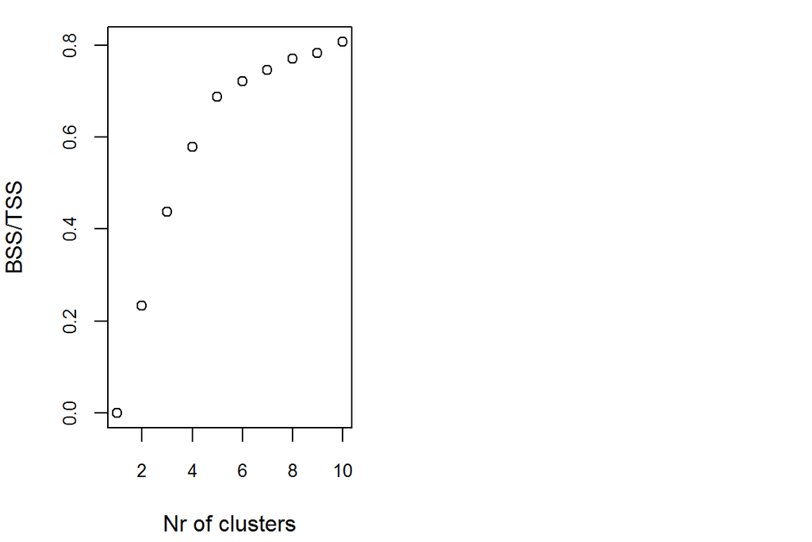

```r
par(mar=c(4.2,4,1,2), cex.axis=0.8, mfrow=c(1,2))
plot(Finland.BW, xlab="Nr of clusters", ylab="BSS/TSS")
```

Plot the increments in between-cluster variance:

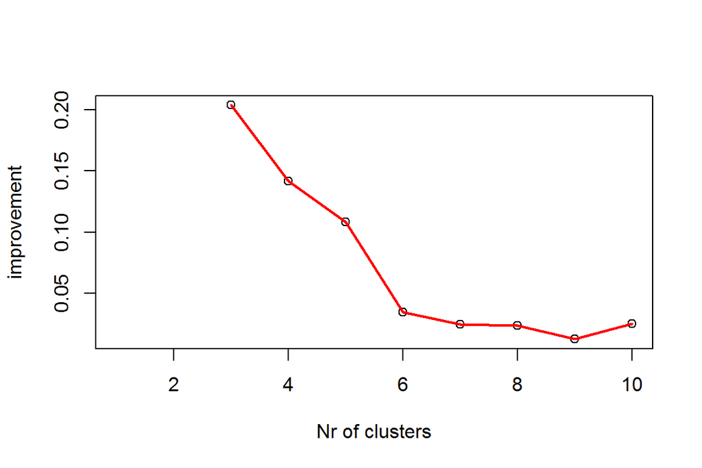

```r
Finland.BWinc <- Finland.BW[2:10]-Finland.BW[1:9]
plot(1:10, c(NA,NA, Finland.BWinc[2:9]), xlab="Nr of clusters", ylab="improvement")
lines(3:10, Finland.BWinc[2:9], col="red", lwd=2)
```

If it looks like 5-cluster solution, than it is a good choice

```r
Finland.km5 <- kmeans(Finland.rpc[,1:4], centers=5, nstart=20, iter.max=200)
Finland.km5$betweenss/Finland.km5$totss
```

```
## [1] 0.6871295
```

Cluster sizes:

```r
Finland.km5$size
```

```
## [1] 212 105 230 210 167
```

```r
Finland.means <- matrix(0,nrow=5,ncol=4)
rownames(Finland.means) <- c("clus1","clus2","clus3","clus4","clus5")
colnames(Finland.means) <- colnames(Finland)[1:4]
for(j in 1:4) Finland.means[,j] <- tapply(Finland[,j], Finland.km5$cluster, mean)
round(Finland.means,1)
```

```
##         A   B   C   D
## clus1 2.8 2.8 1.8 2.5
## clus2 2.2 1.2 3.4 3.3
## clus3 3.6 3.7 1.5 2.5
## clus4 2.6 2.1 2.1 2.4
## clus5 4.4 4.8 1.1 2.2
```

# Used and useful links

[Linting, M., Meulman, J.J., Groenen, P.J.F., & Van der Kooij, A.J. (2007). Nonlinear principal components analysis: Introduction and application. Psychological Methods](https://openaccess.leidenuniv.nl/bitstream/handle/1887/12386/Chapter2.pdf?sequence=10)

[Homogeneity Analysis in R:The Package homals](http://gifi.stat.ucla.edu/janspubs/2007/reports/deleeuw_mair_R_07b.pdf)

[Oleg Nenadic and Michael Greenacre, Computation of Multiple Correspondence Analysis, with code in R](https://core.ac.uk/download/pdf/6591520.pdf)

[Michael Greenacre, Biplots in practice](http://www.multivariatestatistics.org/biplots.html)

Multiple Correspondence Analysis Essentials: Interpretation and application to investigate the associations between categories of multiple qualitative variables - R software and data mining

Mike Bendixen, A Practical Guide to the Use of Correspondence Analysis in Marketing Research, Marketing Bulletin, 2003, 14, Technical Note 2.

Michael Greenacre, Correspondence Analysis in Practice, Third Edition

[An Example R Markdown](http://www.statpower.net/Content/310/R%20Stuff/SampleMarkdown.html)

[Writing Mathematic Formulas in Markdown](http://csrgxtu.github.io/2015/03/20/Writing-Mathematic-Fomulars-in-Markdown/)